# Fantacalcio Analysis

Angelo

2023-06-11

Here is the libraries implemented to realize the analysis: tidyverse, Janitor, tidymodels, FactoMineR, Factoextra.

Our objective is to create an index that can summarize the footballer’s principal Fantacalcio covariate. First of all Fantacalcio is a fantasy football game played in Italy concerning the creation of a squad based on Serie A. Fantasquad’s performance is strictly connected to the real player’s performance in Serie A in every round, concerning also the addition or subtraction of bonus like goals or assists and malus such as yellow cards or red cards. Our analysis concerns the study of these variables:

```r
Calciatori <- read_excel("C:/Users/redbu/Desktop/Fanta Analysis/Calciatori.xls")
Calciatori$`Media `=as.numeric(Calciatori$`Media `)
Calciatori$`FM `=as.numeric(Calciatori$`FM `)
glimpse(Calciatori)
```

```
## Rows: 678
## Columns: 15
## $ `Nome `          <chr> "Audero", "Bardi", "Carnesecchi", "Cerofolini", "Cons…
## $ `Squadra `       <chr> "Sampdoria", "Bologna", "Cremonese", "Fiorentina", "S…
## $ `Media `         <dbl> 6.34, 6.00, 6.41, 6.10, 6.13, 7.00, 5.50, 6.31, 6.34,…
## $ `FM `            <dbl> 4.92, 6.00, 4.69, 5.50, 4.56, 7.00, 2.50, 5.01, 4.85,…
## $ presenze         <dbl> 25, 1, 27, 5, 35, 1, 1, 37, 34, 38, 1, 7, 14, 22, 1, …
## $ `Gol `           <dbl> 0, 0, 0, 0, 0, 0, 0, 0, 0, 0, 0, 0, 0, 0, 0, 0, 0, 0,…
## $ `gol subiti`     <dbl> 39, 0, 47, 3, 55, 0, 3, 49, 54, 46, 2, 6, 18, 21, 2, …
## $ `Ass. `          <dbl> 0, 0, 1, 0, 0, 0, 0, 1, 1, 0, 0, 0, 0, 0, 0, 0, 0, 0,…
## $ cart_gialli      <dbl> 1, 0, 1, 0, 0, 0, 0, 0, 1, 2, 0, 0, 0, 0, 0, 0, 0, 4,…
## $ cart_rossi       <dbl> 0, 0, 0, 0, 0, 0, 0, 0, 0, 0, 0, 0, 0, 0, 0, 1, 0, 0,…
## $ Rigori           <dbl> 0, 0, 0, 0, 0, 0, 0, 0, 0, 0, 0, 0, 0, 0, 0, 0, 0, 0,…
## $ `rigori segnati` <dbl> 0, 0, 0, 0, 0, 0, 0, 0, 0, 0, 0, 0, 0, 0, 0, 0, 0, 0,…
## $ `rigori parati`  <dbl> 2, 0, 0, 0, 0, 0, 0, 0, 1, 1, 0, 0, 0, 1, 0, 0, 1, 0,…
## $ autogol          <dbl> 1, 0, 0, 0, 0, 0, 0, 0, 0, 0, 0, 0, 0, 0, 0, 0, 0, 0,…
## $ Ruolo            <chr> "P", "P", "P", "P", "P", "P", "P", "P", "P", "P", "P"…
```

Now we can start going through into the core of the analysis filtering the goalkeepers:

```r
calciatori=Calciatori %>%
  clean_names()
portieri=calciatori %>%
  filter(ruolo=="P",presenze!=0,gol_subiti!=0) %>%
  mutate(gol_rateo=(presenze/gol_subiti)*presenze) %>%
  select(-c(media,fm,gol,rigori,rigori_segnati,gol_subiti))
Nome_1=portieri$nome
```

For index’s formulation we excluded variables like penalties because they are meanless where we talk about how good is a goalkeeper. Using presenze and gol_subiti we created a new covariate which allow us to exclude the last one.

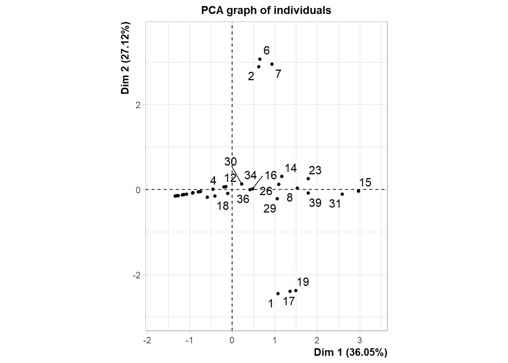

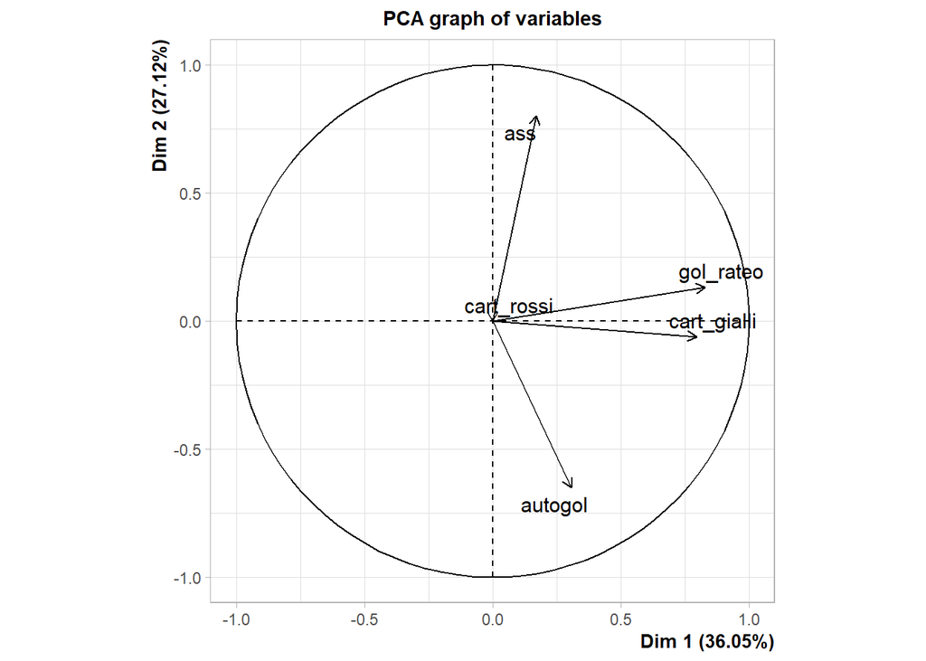

```r
res_pca=PCA(portieri[,c(4,5,6,8,10)],ncp = 2,scale.unit = T)
```

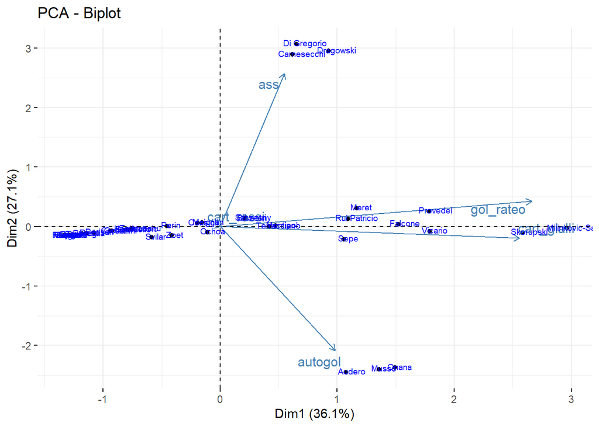

```r
coordinates=as.data.frame(res_pca$ind$coord)
portieri=cbind.data.frame(portieri,coordinates)
biplot=factoextra::fviz_pca_biplot(res_pca,label = "var" ,repel = TRUE)

biplot+geom_text(aes(label=Nome_1),hjust=0.3,vjust=0.3,size=2.5,color="blue")
```

As we can clarily see plotting PCA results there are some goalkeepers who are better in mantain the clean sheet like Provedel or Meret and others who are characterised in having more yellow cards or give more assists to their team-mates. Now we can proceed to index realization

```r
portieri$ind=(portieri$Dim.1/max(portieri$Dim.1))*(portieri$presenze/38)*(1-(portieri$cart_gialli+portieri$cart_rossi+portieri$autogol)/38)
portieri$ind=(portieri$ind-min(portieri$ind))/(max(portieri$ind)-min(portieri$ind))
```

Index is calculated using the first principal component indexed multiplied by a correction factor. Then we used Min-Max method to normalize between 0 and 1, obtaining the following top ten:

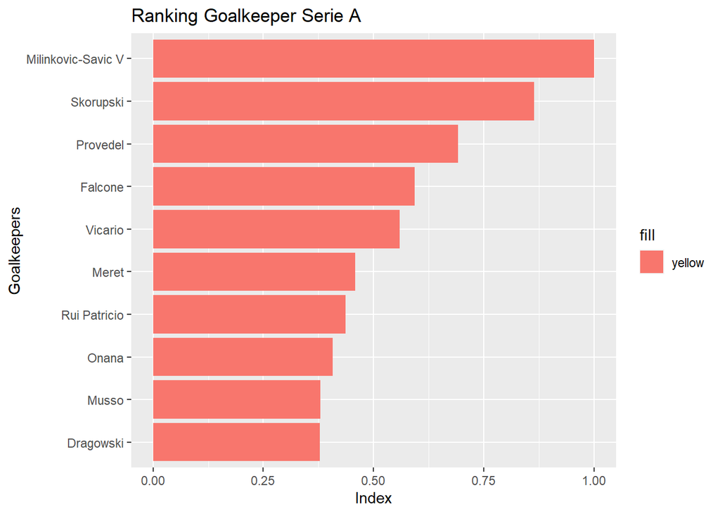

```r
class_por=portieri %>%
  select(nome,ind) %>%
  arrange(desc(ind)) %>%
  head(n=10)
ggplot(data=class_por, aes(x=ind,y=reorder(nome,ind)))+
  geom_bar(stat = "identity",aes(fill="yellow"))+
  ggtitle("Ranking Goalkeeper Serie A")+
  xlab("Index")+
  ylab("Goalkeepers")
```

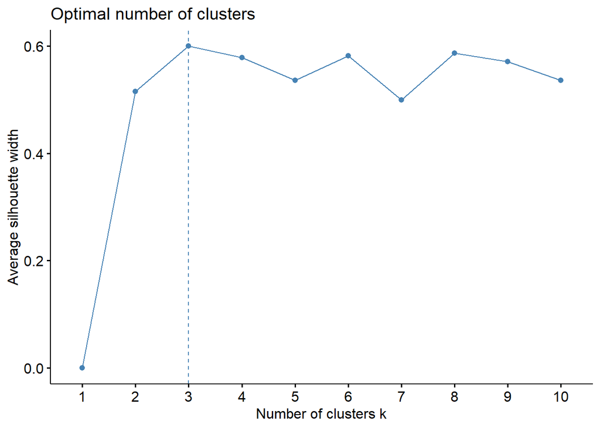

```r
por_clust= portieri %>%
  select(nome,gol_rateo,rigori_parati)%>%
  mutate(across(gol_rateo:rigori_parati,scale))
factoextra::fviz_nbclust(por_clust[,2:3],FUNcluster = kmeans, method="silhouette")
```

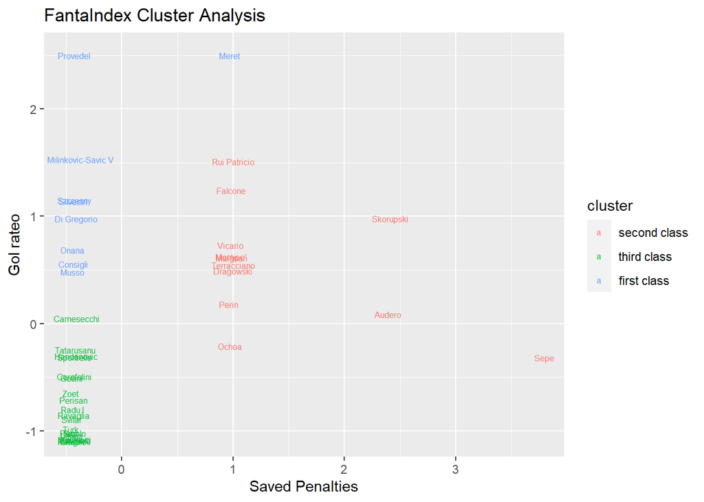

```r
k_res=kmeans(por_clust[,2:3],centers = 3)
por_clust=cbind.data.frame(por_clust,k_res$cluster)

ggplot(data = por_clust, aes(x=rigori_parati,y=gol_rateo,color=factor(k_res$cluster),label=Nome_1
))+
  geom_text(nudge_x = 0.1,nudge_y = 0.1,hjust=0.3,vjust=1,size=2.1)+
  labs(title = "FantaIndex Cluster Analysis", x="Saved Penalties",y="Gol rateo",color="cluster")+
  scale_color_discrete(name="cluster", labels=c("second class","third class",
                                                "first class"))
```

As we can see there are 3 classes of goalies: 1) Goalies with high gol rateo, which assures a good performance all the matches; 2)Goalies with a good gol rateo but with more saved penalties that guarantees some good performances but they are not constant. 3)Goalies with bad gol rateo and few saved penalties who are the worst goalkeepers.

Now we will do similar analysis for the other roles, going forward with defenders, then midfielders and forwarders.

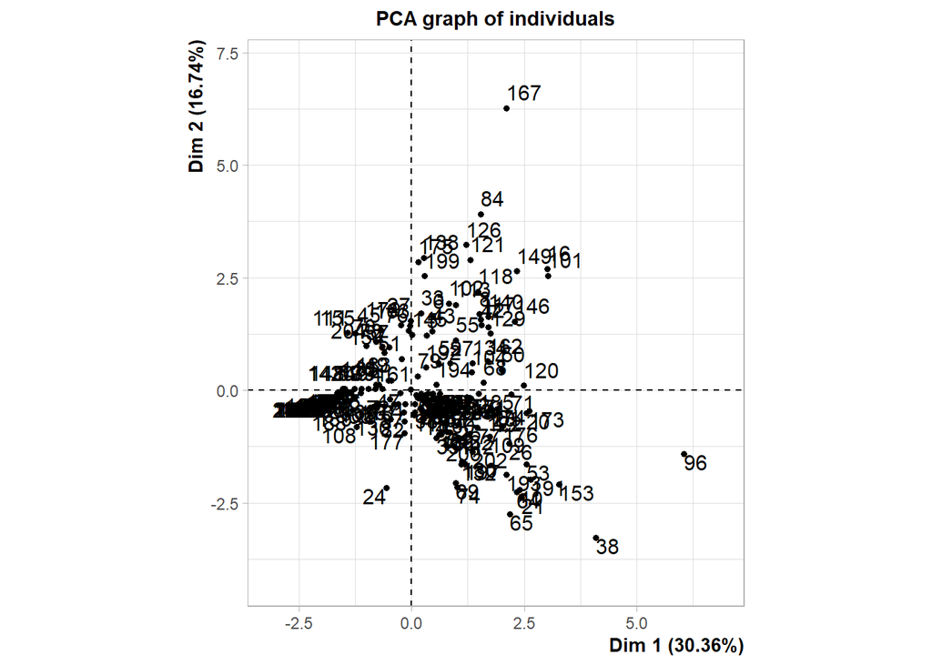

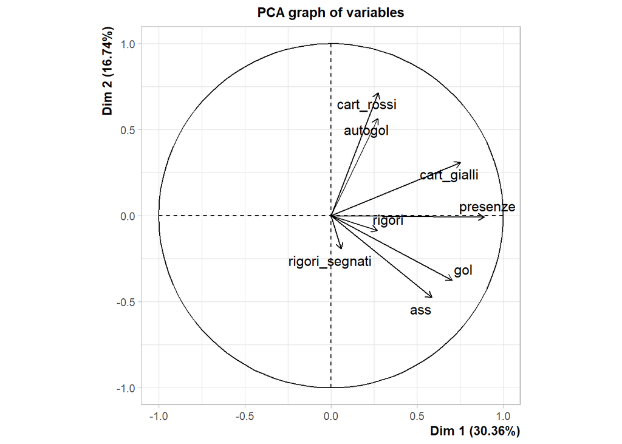

```r
difensori=calciatori %>%
  filter(ruolo=="D") %>%
  select(-c(media,fm,gol_subiti,rigori_parati))
Nome_2=difensori$nome
res_pca=PCA(difensori[,c(3,4,5,6,7,8,9,10)],ncp = 2,scale.unit = T)
```

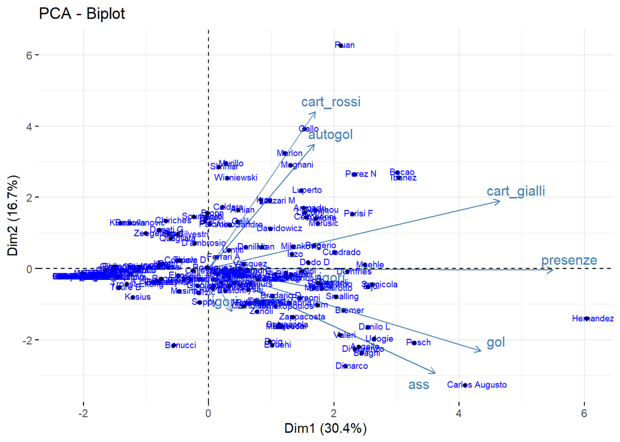

```r
coordinates=as.data.frame(res_pca$ind$coord)
difensori=cbind.data.frame(difensori,coordinates)
biplot=factoextra::fviz_pca_biplot(res_pca,label = "var" ,repel = TRUE)

biplot+geom_text(aes(label=Nome_2),hjust=0.3,vjust=0.3,size=2.5,color="blue")
```

We can see defenders like Theo and Carlos Augusto are some of the best because they accumulate more goals and assists and others like Ibanez or Becao are good because they played almost all the matches.

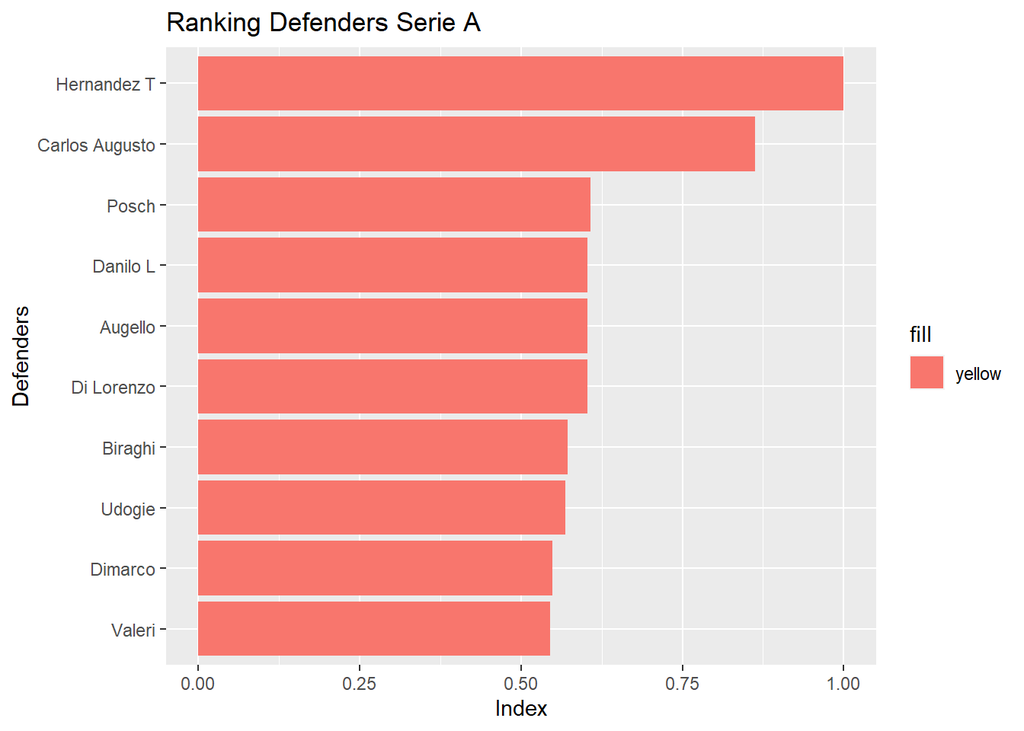

```r
difensori$ind=(difensori$Dim.1/max(difensori$Dim.1))*(difensori$presenze/38)*(1-(difensori$cart_gialli+difensori$cart_rossi+difensori$autogol)/38)
difensori$ind=(difensori$ind-min(difensori$ind))/(max(difensori$ind)-min(difensori$ind))
class_dif=difensori %>%
  select(nome,ind) %>%
  arrange(desc(ind)) %>%
  head(n=10)
ggplot(data=class_dif, aes(x=ind,y=reorder(nome,ind)))+
  geom_bar(stat = "identity",aes(fill="yellow"))+
  ggtitle("Ranking Defenders Serie A")+
  xlab("Index")+
  ylab("Defenders")
```

Index shows us Carlos Augusto e Theo Hernandez were the best defenders because they have brought the major number of goals and assists during the season combined with good performances. Let’s move to midfielders:

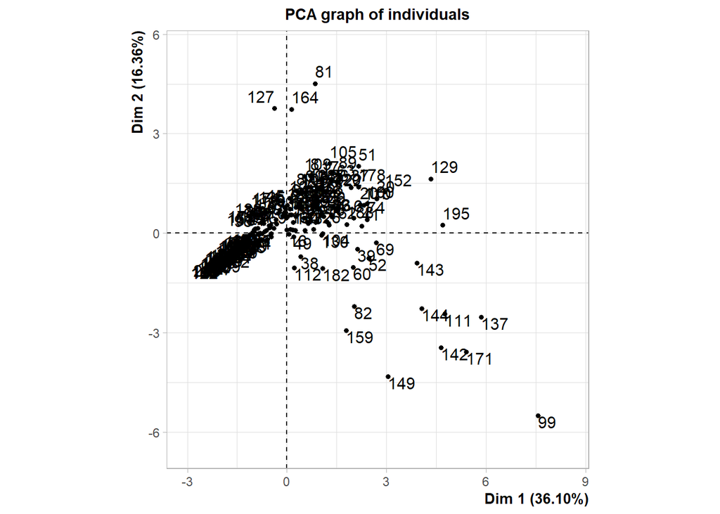

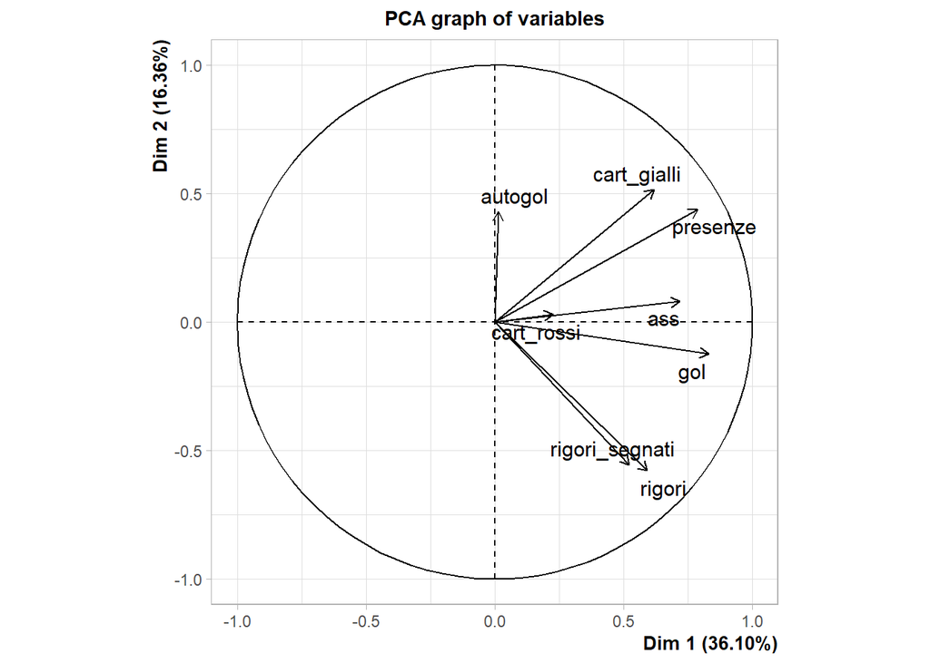

```r
centrocampisti=calciatori %>%
  filter(ruolo=="C") %>%
  select(-c(media,fm,gol_subiti,rigori_parati))
Nome_3=centrocampisti$nome
res_pca=PCA(centrocampisti[,c(3:10)],ncp = 2,scale.unit = T)
```

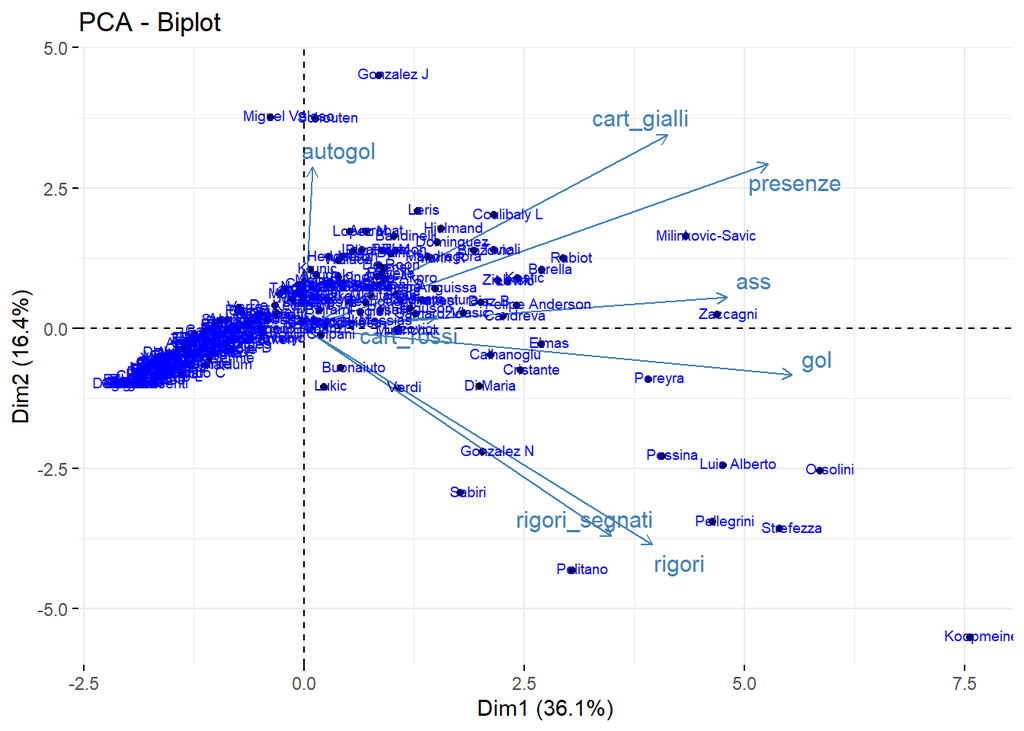

```r
coordinates=as.data.frame(res_pca$ind$coord)
centrocampisti=cbind.data.frame(centrocampisti,coordinates)
biplot=factoextra::fviz_pca_biplot(res_pca,label = "var" ,repel = TRUE)
biplot+geom_text(aes(label=Nome_3),hjust=0.3,vjust=0.3,size=2.5,color="blue")
```

Midfielders on the right side are the most consistent players in the league such as Koopmeiners, Zaccagni, Milinkovic-Savic, Orsolini or Strefezza who had a lot of goals and assists. Now let’s build the index using the first princal component and plot bars showing the top ten:

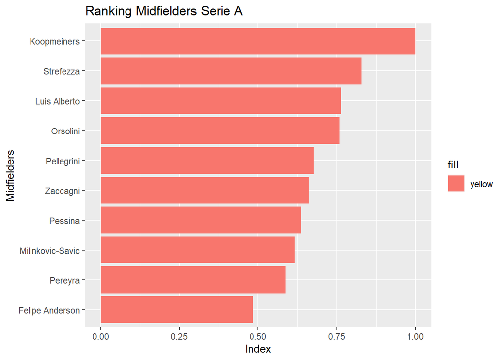

```r
centrocampisti$ind=(centrocampisti$Dim.1/max(centrocampisti$Dim.1))*(centrocampisti$presenze/38)*(1-(centrocampisti$cart_gialli+centrocampisti$cart_rossi+centrocampisti$autogol)/38)
centrocampisti$ind=(centrocampisti$ind-min(centrocampisti$ind))/(max(centrocampisti$ind)-min(centrocampisti$ind))
class_c=centrocampisti %>%
  select(nome,ind) %>%
  arrange(desc(ind)) %>%
  head(n=10)
ggplot(data=class_c, aes(x=ind,y=reorder(nome,ind)))+
  geom_bar(stat = "identity",aes(fill="yellow"))+
  ggtitle("Ranking Midfielders Serie A")+
  xlab("Index")+
  ylab("Midfielders")
```

According to the index the best midfielder of last season was Koopmeiners but all these goals are scored with penalties with 2 hattricks, so in term of consistency maybe for the squad midfielders like Orsolini, Milinkovic-Savic or Pereyra are better. Finally we go through with forwarders:

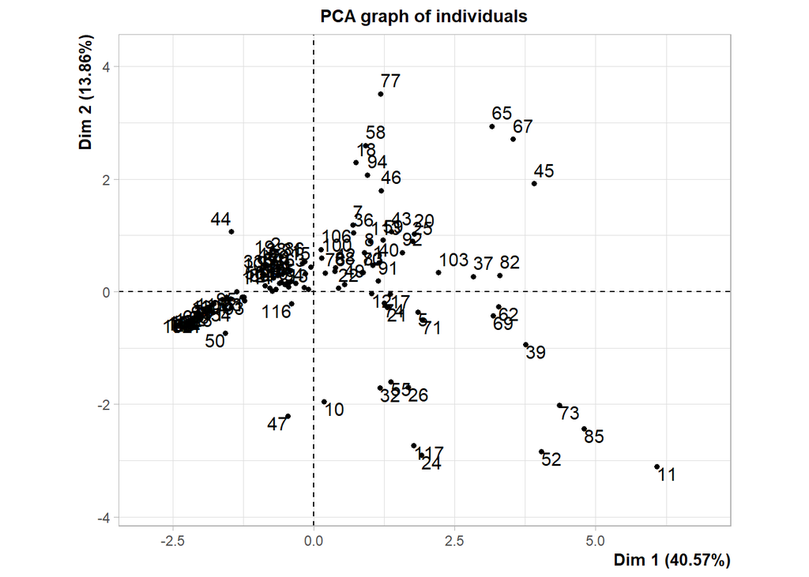

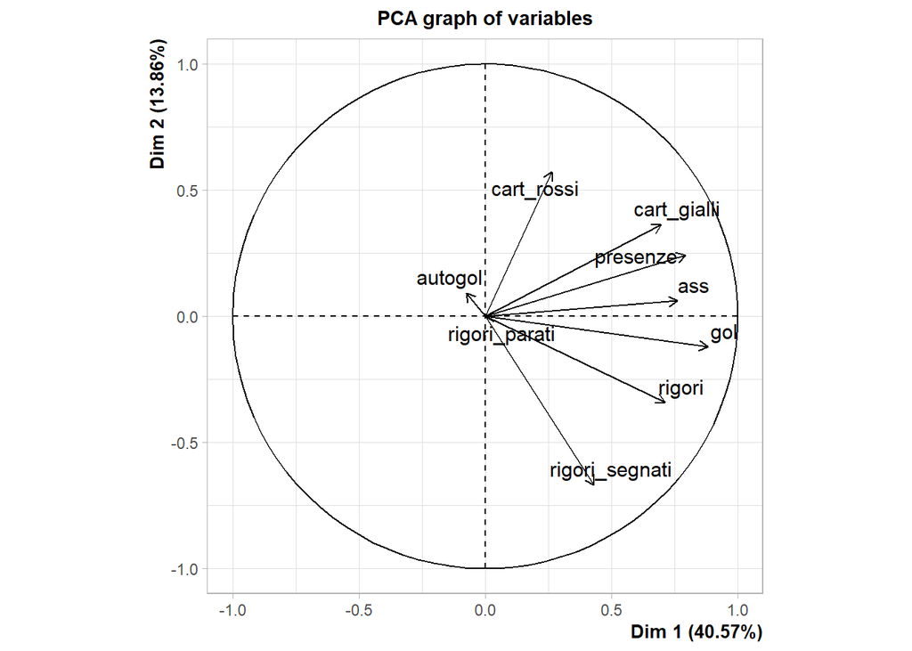

```r
attaccanti=calciatori %>%
  filter(ruolo=="A") %>%
  select(-c(media,fm,gol_subiti))
Nome_4=attaccanti$nome
res_pca=PCA(attaccanti[,c(3,4,5,6,7,8,9,10,11)],ncp = 2,scale.unit = T)
```

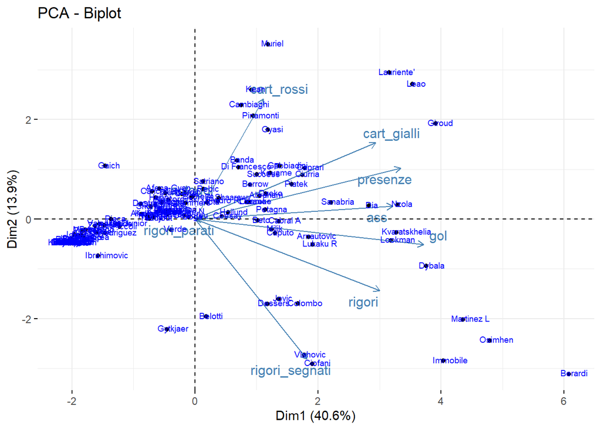

```r
coordinates=as.data.frame(res_pca$ind$coord)
attaccanti=cbind.data.frame(attaccanti,coordinates)
biplot=factoextra::fviz_pca_biplot(res_pca,label = "var" ,repel = TRUE)

biplot+geom_text(aes(label=Nome_4),hjust=0.3,vjust=0.3,size=2.5,color="blue")
```

Among forwarders, in term of G/A, Berardi, Osimhen and Lautaro have guaranteed best performances bringing a lot of bonuses together with some surprising players at their first season in Serie A like Kvara, Lookman and Dia, paid less than top tier forwarders. Now let’s check the results given by the index built using the first dimension:

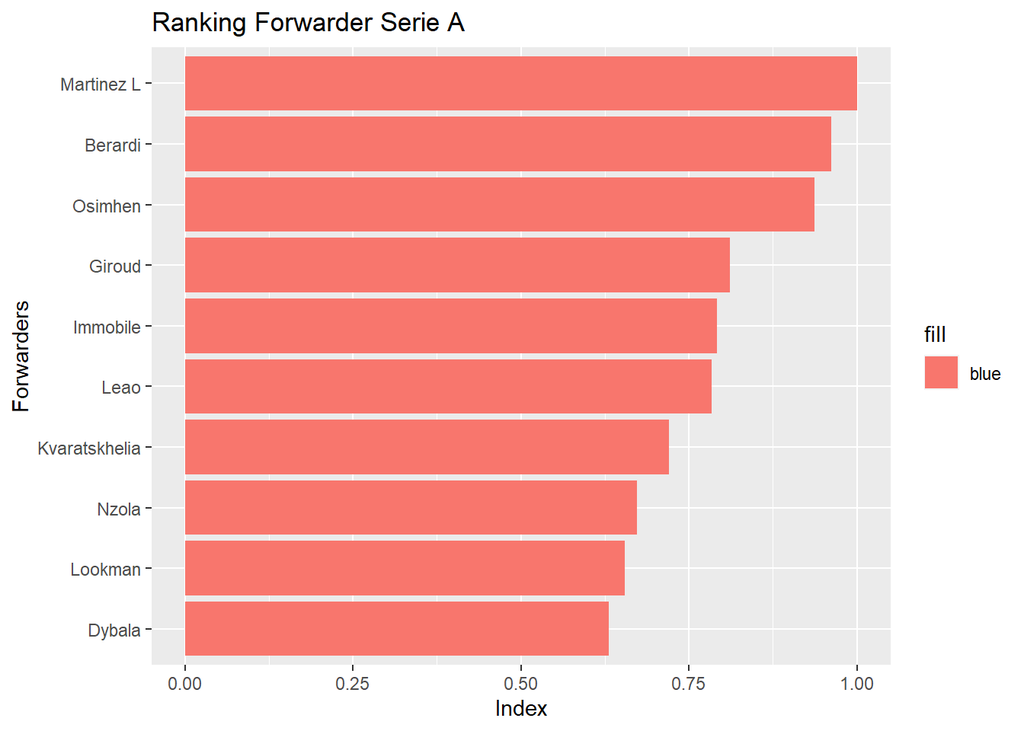

```r
attaccanti$ind_att=(attaccanti$Dim.1/max(attaccanti$Dim.1))*(attaccanti$presenze/38)
attaccanti$ind_att=(attaccanti$ind_att-min(attaccanti$ind_att))/(max(attaccanti$ind_att)-min(attaccanti$ind_att))
class_att=attaccanti %>%
  select(nome,ind_att) %>%
  arrange(desc(ind_att)) %>%
  head(n=10)
ggplot(data=class_att, aes(x=ind_att,y=reorder(nome,(ind_att))))+
  geom_bar(stat = "identity",aes(fill="blue"))+
  ggtitle("Ranking Forwarder Serie A")+
  xlab("Index")+
  ylab("Forwarders")
```

Even if Osimhen has scored more goals than Lautaro he resulted more consistent during all the season giving more assists than Napoli’s forwarder. In Fantacalcio building a solid forward unit can be a good strategy to win it without taking less attention to other roles, especially the goalies because they can bring generally more malus than bonus. A good squad is composed by a mixture of very good players that already know Serie A which bring a lot of bonus and quite good players with less bonuses but characterised by consistency and long period good performances.